# Newtown 2017 House Prices Report

Project 1

SID:** 500459007

University of Sydney | DATA1001 | September 2020

# 1 Executive Summary

From the data analysis and report, it is evident that the price of properties is affected by different variables such as number of bedrooms, carspots etc.

Properties in Newtown are rather expensive (average price: $1.4 mil), with the cheapest being $370k and the most expensive being $3.15 mil.

# 2 Full Report

## 2.1 Initial Data Analysis (IDA)

The Newtown property prices dataset comes from data scraped by domain in June 2017.

### 2.1.1 Source:

The data is sourced from Domain, a reputable and legitimate Australian digital property portal.

In terms of the data collected, there is a possibility of:

- Human error during entering data in the system
- Miscalculations or misinterpretation of data
- False or invalid data entry

### 2.1.2 Structure

The data has 56 objects with 8 variables

```r
property = read.csv("http://www.maths.usyd.edu.au/u/UG/JM/DATA1001/r/current/data/NewtownJune2017.csv")
dim(property)
```

```
## [1] 56  8
```

```
## 'data.frame':    56 obs. of  8 variables:
##  $ ï..Property: chr  "19 Watkin Street Newtown" "30 Pearl Street Newtown" "26 John Street Newtowmn" "23/617-623 King Street Newtown" ...
##  $ Type       : chr  "House" "House" "House" "Apartment" ...
##  $ Agent      : chr  "RayWhite" "RayWhite" "Belle" "RayWhite" ...
##  $ Bedrooms   : int  4 2 2 1 1 5 1 1 1 3 ...
##  $ Bathrooms  : int  1 1 1 1 1 1 1 1 1 2 ...
##  $ Carspots   : int  1 0 0 1 1 1 0 1 1 0 ...
##  $ Sold       : int  1975 1250 1280 780 650 2100 675 740 625 1950 ...
##  $ Date       : chr  "23/6/17" "23/6/17" "17/6/17" "17/6/17" ...
```

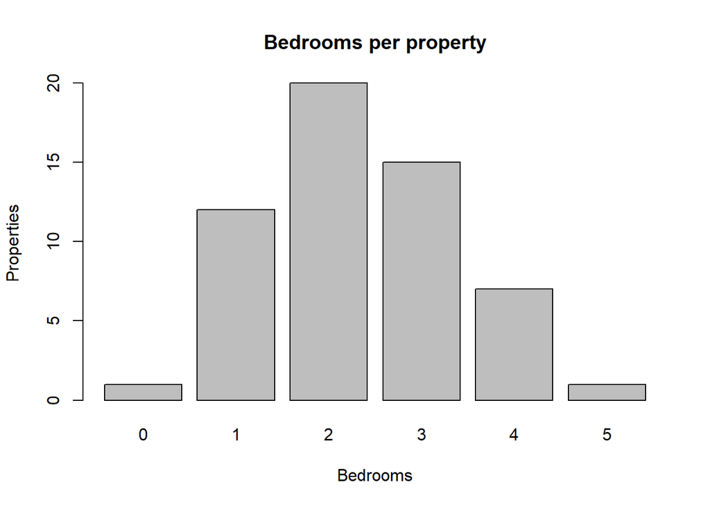

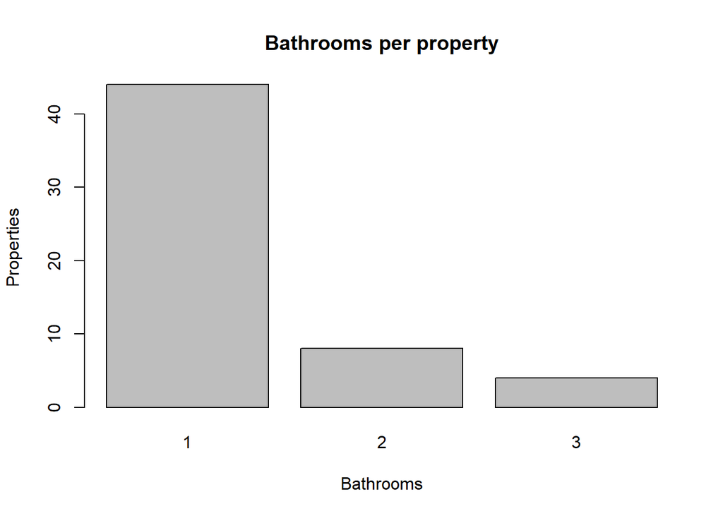

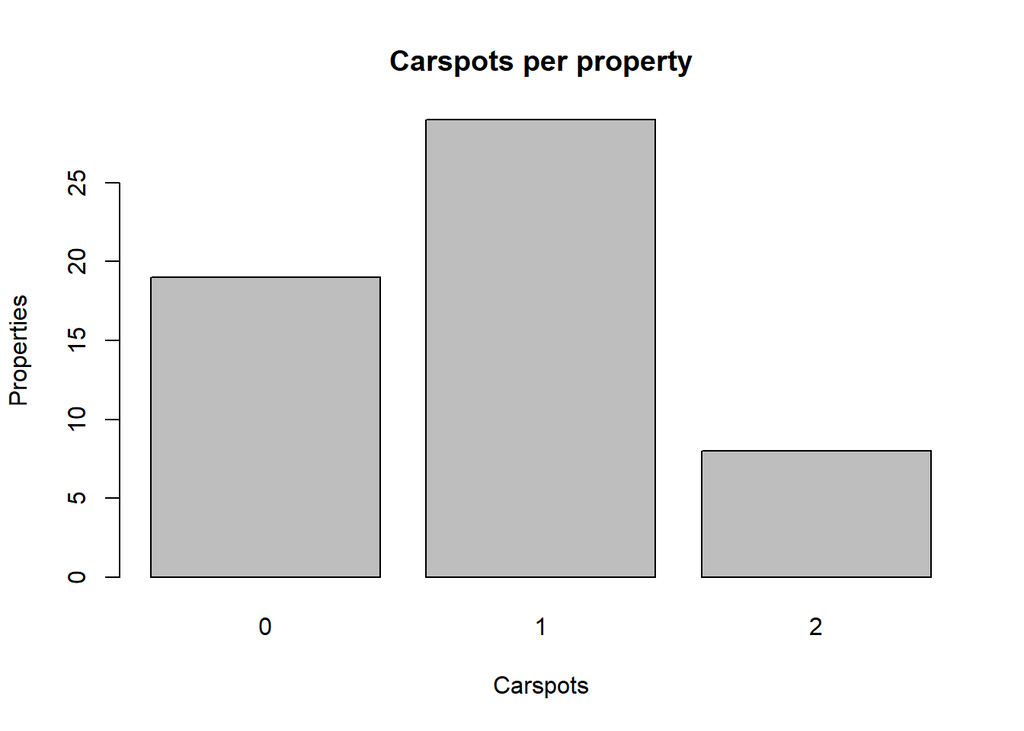

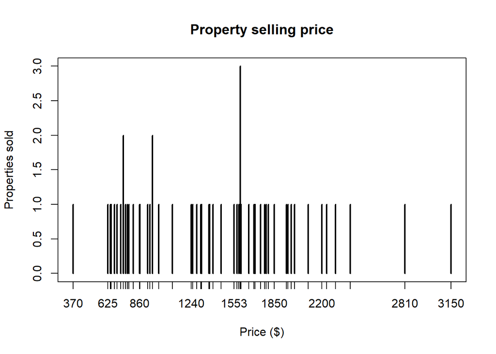

### 2.1.3 Limitations

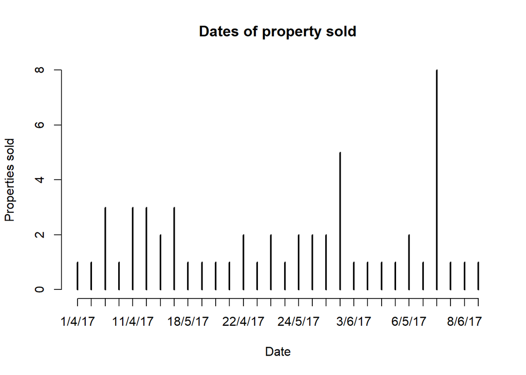

## 2.2 Research Questions (given)

### 2.2.1 What was the average price of a property?

Property average price:

```
## [1] 1407.143
```

Property median price:

```
## [1] 1387.5
```

Standard deviation of prices:

```
## [1] 599.0897
```

IQR of prices:

```
## [1] 921.75
```

### 2.2.2 Does the amount of carspots affect the price?

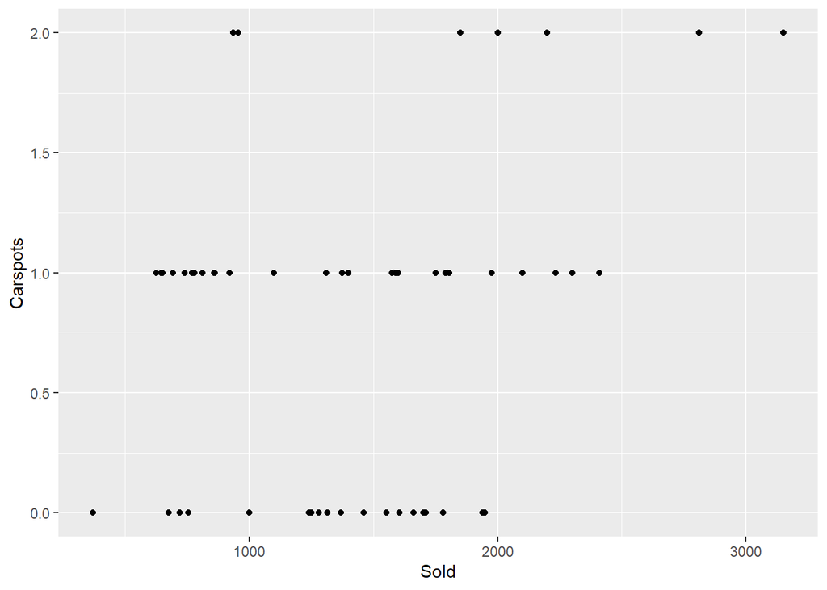

Mean of properties with 1 carspot:

```
## [1] 1331.379
```

Mean of properties with 2 carspots:

```
## [1] 1856.875
```

Mean of properties with no carspots:

```
## [1] 1333.421
```

The amount of carspots **does seem to affect** the price of properties as the mean for properties with 2 carspots is *much higher* than for properties with 1 or no carspots.

However, it is evident that most properties either have 1 or no carspots. This sample **may not be an accurate representation** of the number of carspots affecting the price.

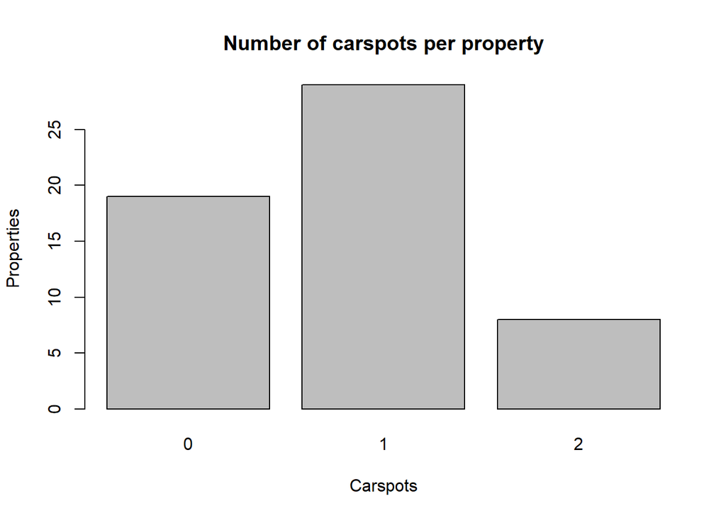

### 2.2.3 What were the cheapest properties?

Properties sorted by price:

```
##  [1]  370  625  645  650  675  692  720  740  740  755  770  780  812  860  861
## [16]  920  935  955  955  999 1100 1240 1250 1280 1309 1315 1370 1375 1400 1460
## [31] 1553 1575 1590 1600 1600 1600 1605 1662 1701 1710 1750 1780 1790 1806 1850
## [46] 1940 1950 1975 2000 2100 2200 2235 2300 2410 2810 3150
```

Cheapest properties

```
##                        ï..Property Carspots Sold
## 19      514/88 King Street Newtown        0  370
## 9  14/163 Australia Street Newtown        1  625
## 38      1/60 Wilson Street Newtown        1  645
## 5      12/2-6 Brown Street Newtown        1  650
## 7  63/3-13 Ersenville Road Newtown        0  675
## 41   113/63-71 Enmore Road Newtown        1  692
## 21 13/20 Fitzgerald Street Newtown        0  720
## 8        4/502 King Street Newtown        1  740
## 53   412/1 Georgina Street Newtown        1  740
## 26    B303/38 Alice Street Newtown        0  755
```

Top 3 cheapest properties were:

- 514/88 King St, $370k
- 14/163 Australia St, $625k
- 1/60 Wilson St, $645k

### 2.2.4 Assuming commission fees are around 2%, which agency earnt the most over that period?

Agent sales:

```
## # A tibble: 18 x 2
##    Agent                  earnings
##    <chr>                     <dbl>
##  1 Belle                      25.6
##  2 BresicWhitney              27.5
##  3 EeRealEstate               79.3
##  4 GerberProperties           35.6
##  5 GreenSquareResidential     19.1
##  6 HarrisPartners             14.8
##  7 Iskandar                   26.3
##  8 LJHooker                  101.
##  9 Martin                     22
## 10 McGrath                    92.4
## 11 OneAgency                  17.2
## 12 PlanetProperties           16.2
## 13 R&W                        84.8
## 14 Raine&Horne               339.
## 15 RayWhite                  348.
## 16 TraversGray                13.5
## 17 Urbane                    219.
## 18 Viewey                     95.4
```

*RayWhite* is the agency with most earnings (347.62)

## 2.3 Research Question (own)

### 2.3.1 Does the number of bedrooms affect the price of properties?

Average price with 1 bedroom:

```
## [1] 732.5833
```

Average price with 2 bedrooms:

```
## [1] 1233.5
```

Average price with 3 bedrooms:

```
## [1] 1831.8
```

Average price with 4 bedrooms:

```
## [1] 2198.857
```

Average price with 5 bedrooms:

```
## [1] 2100
```

Number of bedrooms vs Price

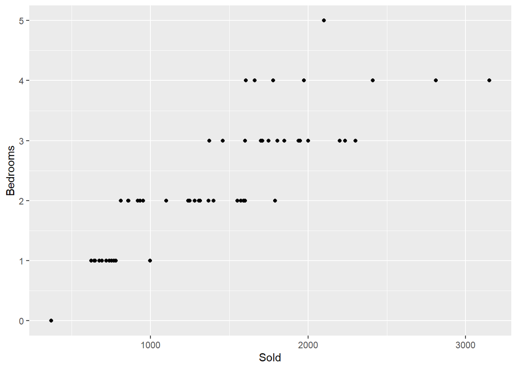

Number of bedrooms in each property **affects the price**.

As **bedrooms increase**, average price **increases**.

Average for 5 bedrooms is *lower* than average for 4 bedrooms as **only 1 property** has 5 bedrooms.

1 property has **no bedrooms**, possibly due to data misinterpretation or it is not for living (a garage).